# Life-Dinner Principle

Dan Conroy-Beam

2023-09-14

## Model Overview

### Purpose

Observe the “life-dinner principle”: in coevolutionary arms races, prey animals have the advantage in that they are fighting for their lives whereas predators are just fighting for dinner.

Agents representing rabbits and foxes will have random encounters with one another. Whether the rabbit escapes–and whether the fox eats–will depend on their relative speed.

Rabbits will reproduce only if they survive; foxes will reproduce only if they get enough to eat.

### Agents

Agents will represent either foxes or rabbits. Each agent will also have a speed variable randomly assigned to them from a normal distribution. Rabbit agents will possess a variable that determines whether they have been eaten; foxes possess a variable that tracks the number of rabbits they have eaten.

### Life Cycle

1. Encounter
2. Eat/escape
3. Reproduce/Die

#### Encounter

During this life stage, each fox will encounter one rabbit at random.

#### Eat/Escape

The model will next determine whether the fox eats its encountered rabbit or whether the rabbit escapes. The model will roll dice for each agent with the maximum value equal to the agent’s speed value.

If the rabbit’s dice roll is higher, the rabbit escapes; otherwise the fox eats the rabbit.

The total number of encounters a fox experiences will be set by a parameter.

#### Reproduce/Die

After encounters are resolved, the agents will reproduce. Rabbits will reproduce only if they survived. Foxes will reproduce in proportion to the number of rabbits they ate.

Offspring will inherit their speed variable from their parents.

### Analysis

The model will compute the average speed of foxes and rabbits within each model run.

## Model

### Packages

```r
library(ggplot2)
```

### Parameters

```r
#Fox Population Size#
#The number of fox agents to generate
foxPop<-100



#Number of Encounters#
#Number of rabbits each fox will encounter in their lifespan
nEncounters<-3



#Rabbit Population#
#The number of rabbit agents to be generated
rabbitPop<-foxPop*nEncounters



#Strength of Selection#
#The ratio of reproductive success between most and least successful fox
selStrength<-.15



#Model Loops#
#Number of times to repeat the model
modelLoops<-10



#Generations#
#Number of generations of evolution to simulate
generations<-100
```

### Functions

```r
#Agent Generation#
#A function to generate agents
agentGenerate<-function(n,animal){

  #Assign each agent a unique ID
  ID<-1:n

  #Generate a random speed for each agent
  speed<-rnorm(n,25,5)

  #If the animal is a rabbit...
  if(animal == "rabbit"){

    #Create a variable to track whether each rabbit has been eaten
    eaten<-rep(0,n)

    #Compile the rabbit agents
    agents<-data.frame(ID,animal,speed,eaten)

  } else {

    #Create a variable to track how many rabbits each fox has caught
    catches<-rep(0,n)

    #Compile the fox agents
    agents<-data.frame(ID,animal,speed,catches)

  }

  #Output the agents
  return(agents)

}



#Encounter#
#A function to simulate fox-rabbit encounters
encounter<-function(foxes,rabbits){

  #Bind fox and rabbit speeds into a matrix
  speedMatrix<-cbind(foxes$speed,rabbits$speed)

  #Determine whether each fox catches their rabbit
  #Rolls dice corresponding to the top speed of each fox and rabbit
  #Returns 1 if the fox outruns the rabbit; 0 otherwise
  catch<-apply(speedMatrix,1,function(x)
    runif(1,0,x[1])>runif(1,0,x[2])
    )

  #Output the results of each encounter
  return(catch)

}



#Reproduction#
#A function to make agents reproduce
reproduction<-function(agents,n,selStrength){

  #If the agents are rabbits...
  if(agents$animal[1]=="rabbit"){

    #Remove rabbits that were eaten
    agents<-agents[agents$eaten==0,]

    #Generate random offspring from surviving rabbits
    offspring<-agents[sample(1:nrow(agents),n,replace=T),]

    #Assign each offspring a unique ID
    offspring$ID<-1:n

  } else {

    #Remove foxes that failed to eat
    agents<-agents[agents$catches>=1,]

    #Sets the lowest catch value to 0
    p<-agents$catches-min(agents$catches)

    #Set the maximum value of p to 1
    p<-p/max(p)

    #Add a constant to each p value
    #So the ratio between max and min = 1+selStrength
    p<-p+(1/selStrength)

    #Generate random offspring from the surviving parent foxes
    offspring<-agents[sample(1:nrow(agents),n,replace=T,prob=p),]

    #Assign offspring new unique IDs
    offspring$ID<-1:n

    #Reset offspring hunting success to 0
    offspring$catches<-0

  }

  #Output the offspring
  return(offspring)

}
```

### Life Cycle

```r
#Generate a blank dataframe to store model results
results<-data.frame("loop"=rep(1:modelLoops,each=generations*2),
                    "generation"=rep(1:generations,times=2),
                    "animal"=rep(c("fox","rabbit"),each=generations,times=modelLoops),
                    "speed"=NA)

#Loop over model loops...
for (m in 1:modelLoops) {

  #Generate the foxes
  foxes <- agentGenerate(foxPop, "fox")


  #Generate the rabbits
  rabbits <- agentGenerate(rabbitPop, "rabbit")

  #Loop over generations...
  for (g in 1:generations) {

    #Loop through the total number of encounters
    for (e in 1:nEncounters) {

      #Encounter#

      #Determine which rabbits each fox encounters
      encountered <- sample(rabbits$ID[rabbits$eaten == 0], foxPop)



      #Eat/Escape#

      #Determine whether each encountered rabbit gets caught
      caught <-
        encounter(foxes, rabbits[match(encountered, rabbits$ID), ])

      #Update the eaten status for encountered rabbits
      rabbits$eaten[match(encountered, rabbits$ID)] <- caught

      #Update the catches status for each fox
      foxes$catches <- foxes$catches + caught

    }

    #Have the rabbits reproduce
    rabbits <- reproduction(rabbits, rabbitPop, selStrength)

    #Have the foxes reproduce
    foxes <- reproduction(foxes, foxPop, selStrength)

    #Store the average speed of animals in this generation and model loop
    results$speed[results$animal=="fox" &
                    results$generation==g &
                    results$loop==m]<-mean(foxes$speed)

    results$speed[results$animal=="rabbit" &
                    results$generation==g &
                    results$loop==m]<-mean(rabbits$speed)

  }

}
```

### Analysis

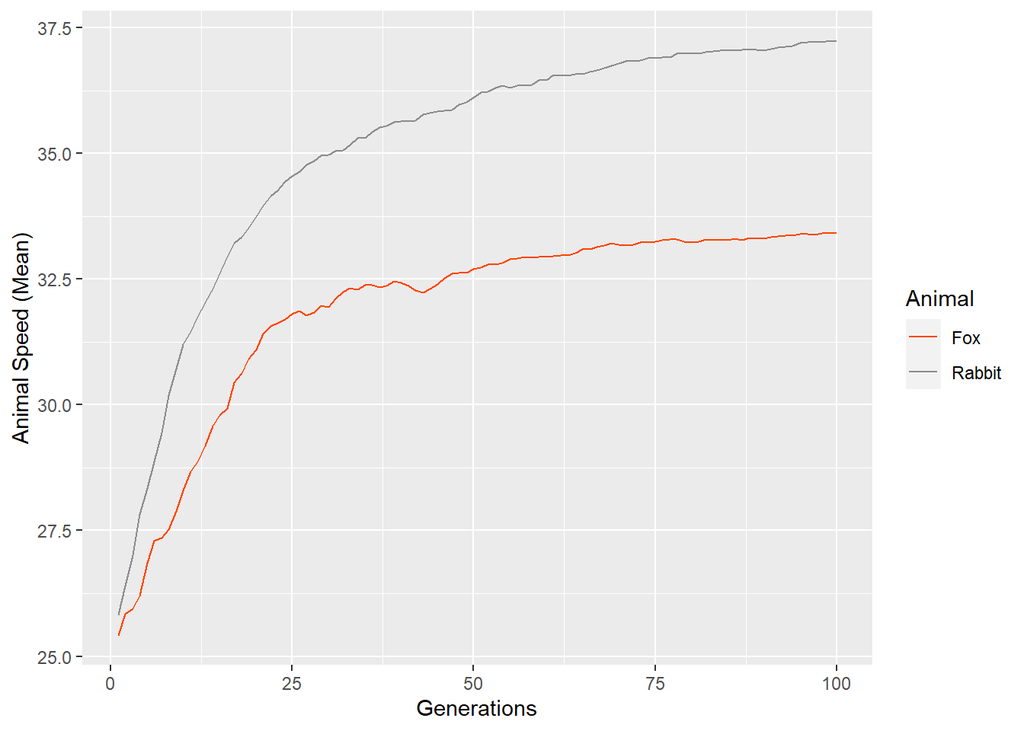

```r
p1<-ggplot(data=results,
           aes(x=generation,
               y=speed,
               color=animal))+
  labs(x="Generations",y="Animal Speed (Mean)",color="Animal")+
  stat_summary(fun=mean,geom="line")+
  scale_color_manual(labels=c("Fox","Rabbit"),
                     values=c("orangered","gray55"))

p1
```